# 第14回 コレスポンデンス分析（対応分析）を実装する

## 前回からの接続

第9回・第10回は、数の列（顔の明るさ、車の性能）を主成分（principal component）の地図にしました。第11回・第13回は、数の列を使って、国をグループに分けました。

今日のデータには、数の列がありません。映画の「ジャンル」と「公開の年代」という、2つの区分を数えた表だけです。それでも、「どのジャンルと、どの年代が近いか」を1枚の地図で読めます。その方法が対応分析（correspondence analysis）です。今日は、これまでに学んだ書き方を総ざらいしながら進めます。

## 今日の分析目標

あなたは映画配信サービスの企画担当者です。「年代別の特集」を組むとき、どの年代にどのジャンルを合わせれば、その時代らしさが出るかを、1枚の地図と数で示したい。

ジャンルと年代に関係があるかを確かめ、対応分析で地図を描き、年代ごとに「多すぎる」ジャンルを数で確かめます。もう1つのねらいは、これまでの書き方を組み合わせて、1つの解析を最後まで書けるようになることです。最後の「目標に答えられたか」で振り返りましょう。

### 場面

あなたは映画配信サービスの企画担当者です。古い映画から新しい映画まで、たくさんの作品を扱っています。次の企画は「年代別の特集」です。

決めたいのは、それぞれの年代の特集に、どのジャンルを並べるかです。その時代らしさが出る組み合わせを、根拠をもって選びたいところです。

### 手元のデータ

MovieLens（F. M. Harper and J. A. Konstan, 2015）の映画の一覧から、映画をジャンルと公開の年代で数えた表です。1行が1つのジャンル、1列が1つの年代で、10行 × 9列です。1つのマスが映画の本数で、ジャンルを複数持つ映画は、それぞれのジャンルで数えています。答えの列はありません。

### 最後に出す答え

年代ごとに、合わせるジャンルを並べた企画の一文です。その根拠として、1枚の地図と、その年代に多いジャンルを示す数を出します。

## 学習ゴール

この回を終えると、次のことができるようになります。

- クロス表の「期待度数（expected frequency）」を計算し、カイ二乗で2つの区分の関係を確かめられる
- 対応分析で、行（ジャンル）と列（年代）を1枚の地図に置き、寄与率（proportion of variance explained）を読める
- 「実際 ÷ 期待」の倍率で、地図の読みを数で確かめられる
- これまでに学んだ書き方（配列の計算、`def`、`for`、辞書、f-string）を組み合わせて使える

## 0. 設定

### 最初に実行する：道具を呼び出す設定のセル

- 役割：このノートで使う道具を呼び出す。対応分析の道具`prince`はColabに入っていないので、なければ入れる
- 入力：なし
- 出力：「セットアップ完了」の表示

```python
import importlib.util
if importlib.util.find_spec('prince') is None:   # 無ければ入れる
    %pip install -q prince
import numpy as np
import pandas as pd
import matplotlib.pyplot as plt
from scipy.stats import chi2_contingency
import prince

!pip install -q japanize-matplotlib   # 図中の日本語が □ になるのを防ぐ
try:
    import japanize_matplotlib
except Exception:   # japanize が動かなくなったときの保険：同梱フォントを直接登録する
    from importlib.util import find_spec
    from matplotlib import font_manager as fm
    from pathlib import Path
    spec = find_spec('japanize_matplotlib')
    ttf = next(Path(spec.origin).parent.rglob('*.ttf'), None) if spec else None
    if ttf:
        fm.fontManager.addfont(str(ttf))
        plt.rcParams['font.family'] = fm.FontProperties(fname=str(ttf)).get_name()

plt.rcParams['figure.figsize'] = (7, 5)
plt.rcParams['font.size'] = 13
plt.rcParams['axes.unicode_minus'] = False   # マイナス記号の化けを防ぐ
print('セットアップ完了')
```

```
セットアップ完了
```

### 分析の地図：今日はここ

データ解析は「① データの理解と目標の設定 → ② 前処理（preprocessing）とデータ解析 → ③ 結果の解釈と目標との整合」の3つのフェーズを回ります。今日は、①から③までを全部回ります。

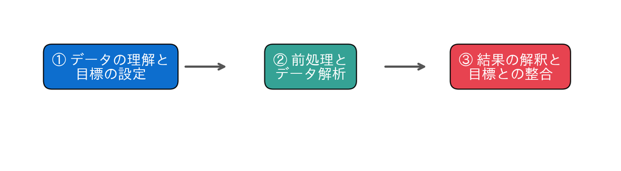

## 1. ジャンルと年代に、関係はあるか

地図を描く前に、まず、ジャンルと年代に関係があるかを数で確かめます。MovieLensのデータから、映画をジャンル（10種類）と公開の年代（1930〜2010年代）で数えたクロス表です。1つのマスが、そのジャンル・その年代の映画の本数です。

### お手本：クロス表を読み込み、カイ二乗で確かめる

- 役割：クロス表を読み込み、ジャンルと年代に関係があるかを、カイ二乗検定で確かめる
- 入力：データの置き場所とファイル名
- 出力：クロス表`ct`、カイ二乗の値・自由度（degrees of freedom）・p値（p-value）

ジャンルと年代に関係がないなら、どの年代でも、ジャンルの割合は同じになるはずです。そのとき各マスに入るはずの本数を期待度数と呼びます。カイ二乗は、実際の本数と期待度数のずれを、1つの数に集めたものです。

$$\chi^2 = \sum \frac{(\text{実際} - \text{期待})^2}{\text{期待}}$$

p値は、「関係がない」としたとき、これ以上大きなずれが偶然に起きる確率です。小さいほど、「関係がない」とは考えにくくなります。`chi2_contingency`は、カイ二乗・p値・自由度・期待度数の4つを返します。

```python
# データはこのリポジトリから読み込む
DATA_DIR = ('https://raw.githubusercontent.com/k0heiun0/'
            'applied_exercise_preview/main/shared/data')
ct = pd.read_csv(f'{DATA_DIR}/movielens_genre_decade.csv',
                 index_col=0)
ct.columns = ct.columns.astype(str)   # 年代の名前を文字に
print(ct)
chi2, p, dof, E = chi2_contingency(ct)
print(round(chi2, 1), dof, p)
```

```
           1930  1940  1950  1960  1970  1980  1990  2000  2010
genre
Action        8     8    15    56   103   227   392   549   464
Adventure    13    13    30    65    71   170   239   363   292
Comedy       53    55    67   132   155   492   890  1135   758
Crime        15    29    29    43    70   124   264   404   218
Drama        74   118   146   192   225   439  1038  1365   743
Fantasy       8    11    11    25    31   106   149   252   178
Horror        9    12    25    40    63   176   160   298   190
Romance      48    54    64    60    44   154   422   523   217
Sci-Fi        3     2    35    35    59   156   173   266   244
Thriller     11    32    32    49    95   180   420   654   417
548.4 72 1.97641130983306e-74
```

10ジャンル × 9年代、のべ18544本（複数のジャンルを持つ映画は、それぞれのジャンルで数える）。カイ二乗は548.4、自由度72、p値は10のマイナス74乗ほどと、とても小さい値です。「ジャンルと年代に関係がない」とすると、こんなに大きなずれはまず起きません。年代によって、ジャンルの構成は偏っています。

ただし、p値が小さいことは、偏りが「ある」ことを示すだけで、偏りが「どれくらい大きいか」は示しません。本数が多い表では、小さな偏りでもp値はとても小さくなります。どこが、どれくらい偏っているかは、2節の地図と、3節の「実際 ÷ 期待」の倍率で見ていきます。

もう一つ、注意があります。この表は、ジャンルを複数持つ映画をそれぞれのジャンルで数えていて、1本の映画がいくつものマスに入っています。カイ二乗は1本を1つのマスで数えた表を前提にしているので、p値の値そのものは目安として読みます。ここまで小さければ、偏りがあることはまず確かです。

### おさらい：配列の計算

```python
a = np.array([1, 2, 3])
a * 10          # すべての要素に、まとめて計算
```

numpyの配列は、`for`を書かなくても、まとめて計算できるのでした（第2回）。`np.outer(a, b)`は、aの各要素とbの各要素を総当たりでかけた表を作ります。

### TODO①：期待度数を、自分で計算する

関係がないときの期待度数は、「そのジャンルの合計 × その年代の合計 ÷ 総数」です。`ct.sum(axis=1)`（ジャンルの合計）と`ct.sum(axis=0)`（年代の合計）から、`np.outer`で期待度数の表`E2`を作り、`chi2_contingency`が返した`E`と一致するか確かめてください。

```python
# TODO: 期待度数 E2 を自分で計算し、E と一致するか確かめる
# ヒント: n = ct.values.sum()
#         E2 = np.outer(ct.sum(axis=1), ct.sum(axis=0)) / n
#         np.allclose(E, E2)
...;
```

`True`。`chi2_contingency`の中でも、この「行の合計 × 列の合計 ÷ 総数」を計算しています。たとえば、ロマンス（1586本）の1930年代（242本）の期待度数は、1586 × 242 ÷ 18544 ≒ 20.7本。実際は48本なので、期待の2倍以上です。

## 2. 対応分析で、地図を描く

偏りがあることは、カイ二乗でわかりました。では、どこが偏っているのか。対応分析は、「実際 ÷ 期待」のずれの表を、PCAと同じ考え方で、少ない軸に縮める方法です（第9回）。ジャンル（行）も年代（列）も、同じ地図の上に点として置けます。同じ向きに原点から離れているジャンルと年代は、「その年代に、そのジャンルが多い」関係にあります。ただし、これは地図を読む目安です。確かな多さは、3節で「実際 ÷ 期待」の倍率を出して確かめます。

### おさらい：def

```python
def 名前(引数):
    return 戻り値
```

`def`の後ろが関数の名前と引数（入力）、`return`の後ろが戻り値（出力）でした（第3回）。地図を描く手順は、課題でも使うので、関数にしておきます。

### お手本：対応分析をかけて、地図を描く

- 役割：クロス表に対応分析をかけ、ジャンルと年代の座標を求めて、1枚の地図に描く
- 入力：クロス表`ct`
- 出力：対応分析`ca`、ジャンルの座標`rows`、年代の座標`cols`、地図

`prince.CA(n_components=2)`は、2本の軸に縮める対応分析です。`row_coordinates`が行（ジャンル）、`column_coordinates`が列（年代）の座標を返します。

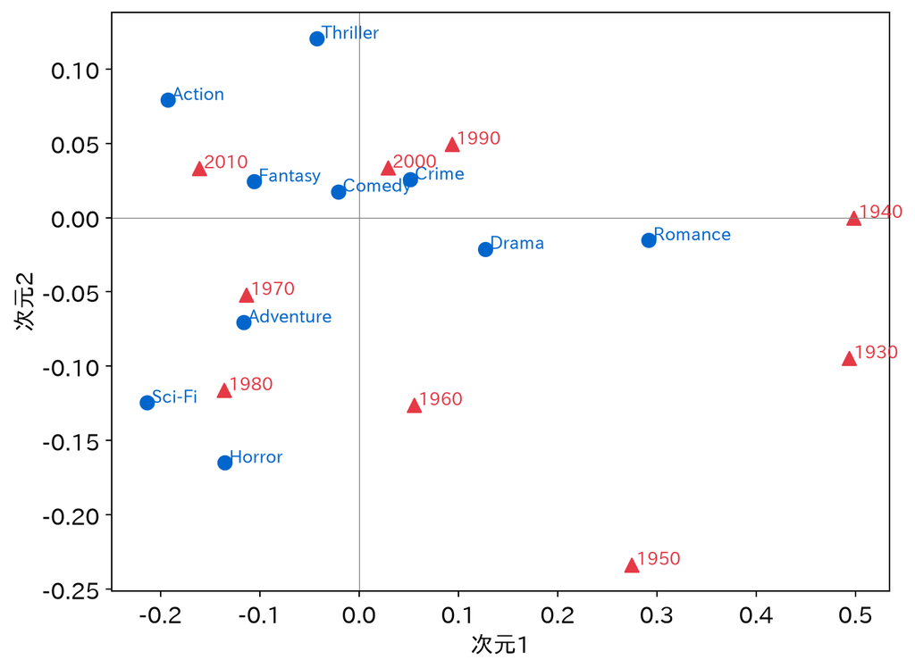

```python
ca = prince.CA(n_components=2, random_state=42).fit(ct)
rows = ca.row_coordinates(ct)                # ジャンルの座標
cols = ca.column_coordinates(ct)             # 年代の座標

def draw_ca(ax, rows, cols):         # ジャンルは青、年代は赤
    ax.scatter(rows[0], rows[1], color='#0066cc', s=60)
    for name, (x, y) in rows.iterrows():
        ax.text(x, y, ' ' + name, color='#0066cc', fontsize=10)
    ax.scatter(cols[0], cols[1], color='#e63946', marker='^', s=60)
    for name, (x, y) in cols.iterrows():
        ax.text(x, y, ' ' + name, color='#e63946', fontsize=10)
    ax.axhline(0, color='gray', lw=0.5)       # 原点を通る線
    ax.axvline(0, color='gray', lw=0.5)
    ax.set_xlabel('次元1'); ax.set_ylabel('次元2')

fig, ax = plt.subplots(figsize=(8, 6))
draw_ca(ax, rows, cols)
plt.show()
```

### TODO②：寄与率を確かめる

この2本の軸で、全体の何割のずれを表せているか（寄与率）を確かめてください。

```python
# TODO: 次元1・次元2の寄与率を表示する
# ヒント: ca.eigenvalues_summary、または ca.percentage_of_variance_
...;
```

次元1が67.3%、次元2が16.6%、合わせて83.9%。2本の軸で、ずれの8割以上を表せています。では、地図を読みます。

横軸（次元1）を見ると、年代は、右の端に古い年代（1930・1940年代が0.5前後）、左に新しい年代（1970・1980・2010年代）と並びます。次元1は時代の軸です。

ただし、「右が古く、左が新しい」と言えるのは両端です。1990年代（＋0.09）と2000年代（＋0.03）は原点のやや右にあり、1990年代は1960年代（＋0.06）より右です。なぜか、年代ごとの本数の割合を確かめてみます。

```python
share = ct.sum() / ct.values.sum()     # 年代ごとの、本数の割合
print(share.round(3))
```

```
1930    0.013
1940    0.018
1950    0.024
1960    0.038
1970    0.049
1980    0.120
1990    0.224
2000    0.313
2010    0.201
dtype: float64
```

1990年代が22.4%、2000年代が31.3%で、2つ合わせて全体の54%です。原点は、全体の平均の構成を表します。全体の平均は、半分以上がこの2つの年代でできているので、2つの年代のジャンルの構成は、平均に近くなりやすいのです。だから、1990年代が1960年代より右にあっても、「1960年代より古い」とは読みません。

ただし、本数が多ければ原点に近い、とは限りません。2010年代も全体の20.1%を占めますが、地図では左の端（−0.16）にいます。地図の位置を決めるのは、その年代のジャンルの構成が、全体の平均とどれだけ違うかです。どれだけ違うかは、3節の倍率で確かめます。

ジャンルでは、ロマンス（0.29）とドラマ（0.13）が右（古い年代の側）、SF（−0.21）とアクション（−0.19）が左（新しい年代の側）にいます。コメディ（−0.02）は原点の近くで、どの年代にも同じくらいある、時代を選ばない定番です。

## 3. 答えを出す：年代別の特集に、どのジャンルを

最初の問いに戻ります。地図の読みを、数でも確かめます。各マスの「実際の本数 ÷ 期待度数」を見れば、そのジャンルがその年代に何倍多いかがわかります。1より大きければ、その年代らしいジャンルです。

### お手本：実際 ÷ 期待の倍率

- 役割：各マスの、実際 ÷ 期待の倍率を表にする
- 入力：`ct`、期待度数`E`
- 出力：倍率の表`ratio`（4つの年代だけ表示）

表どうしの割り算も、配列と同じく、マスごとにまとめて計算されます。

```python
ratio = (ct / E).round(2)      # 1 より大きいほど、その年代に多い
print(ratio[['1930', '1940', '1980', '2010']])
```

```
           1930  1940  1980  2010
genre
Action     0.34  0.24  1.04  1.27
Adventure  0.79  0.57  1.13  1.16
Comedy     1.09  0.82  1.10  1.01
Crime      0.96  1.35  0.86  0.91
Drama      1.31  1.51  0.84  0.85
Fantasy    0.80  0.79  1.15  1.15
Horror     0.71  0.68  1.51  0.97
Romance    2.32  1.89  0.81  0.68
Sci-Fi     0.24  0.11  1.34  1.25
Thriller   0.45  0.94  0.79  1.10
```

1930年代のロマンスは期待の2.32倍、1940年代は、ロマンス（1.89倍）に次いでドラマが1.51倍。1980年代はホラーが1.51倍、SFが1.34倍、2010年代はアクションが1.27倍、SFが1.25倍です。地図で、古い年代の近くにロマンス・ドラマ、新しい年代の近くにアクション・SFが置かれていたことと、合っています。

地図で原点の近くにいた1990年代と2000年代は、どのジャンルも倍率が1に近く、0.74〜1.19倍に収まります。

```python
print(ratio[['1990', '2000']].agg(['min', 'max']))
```

```
     1990  2000
min  0.74  0.87
max  1.19  1.10
```

### おさらい：forと辞書

```python
out = {}
for i in range(3):
    out[i] = i * 10      # out は {0: 0, 1: 10, 2: 20}
```

辞書は、名前（キー）と値の組を覚えておく入れ物でした（第3回）。空の辞書`{}`を作り、`for`で1つずつ取り出しながら、`out[キー] = 値`でキーと値をためていきます。

### TODO③：1950年代と1970年代の上位3ジャンル

`for`で`'1950'`と`'1970'`の2つの年代を取り出し、`ratio`の倍率が高い順に3つのジャンルを、辞書`top3`に`{年代: {ジャンル: 倍率}}`の形でためて表示してください。

```python
# TODO: 1950・1970年代の、倍率の高い3ジャンルを辞書 top3 にためる
# ヒント: top3 = {} → for dec in ['1950', '1970']: の中で
#         s = ratio[dec].sort_values(ascending=False)
#         top3[dec] = s.head(3).to_dict()
...;
```

1950年代は、ロマンス（1.65倍）・SF（1.47倍）・ドラマ（1.37倍）。1970年代は、ホラー（1.31倍）・SF（1.23倍）・犯罪もの（1.18倍）。1950年代にはまだロマンスとドラマが多く、SFが伸びはじめています。1970年代には、ロマンスが減り、ホラーとSFの時代になります。

### おさらい：f-string

```python
n = 3
print(f'{n}個')     # 3個
```

`f'…'`の中の`{}`に、値を埋めこめるのでした（第4回）。

### TODO④：特集の企画書を、一文で書く

1960年代について、`ratio['1960']`の倍率がいちばん高いジャンルといちばん低いジャンルを求め、f-stringで「1960年代の特集は ○○（□倍）を中心に。△△（□倍）は少なめでよい。」という一文を表示してください。

```python
# TODO: 1960年代の倍率が最も高い・低いジャンルで、企画書の一文を作る
# ヒント: r = ratio['1960'].sort_values()
#         いちばん高いのは r.index[-1]、倍率は r.iloc[-1]
#         いちばん低いのは r.index[0]
...;
```

「1960年代の特集はAdventure（1.38倍）を中心に。Thriller（0.69倍）は少なめでよい。」冒険ものが、1960年代らしいジャンルです。

企画担当者としての答えは、年代ごとに次のジャンルを合わせることです。

- 1930〜50年代：ロマンスとドラマ（1930年代のロマンスは期待の2.32倍）
- 1960年代：冒険もの（1.38倍）
- 1970・1980年代：ホラーとSF（1980年代のホラーは1.51倍）
- 2010年代：アクションとSF
- 1990・2000年代：どのジャンルも倍率が1に近い（0.74〜1.19倍）ので、ジャンル以外の切り口も考える
- どの年代にも合う定番：コメディ

根拠は2つです。ジャンルと年代には、はっきりした関係があります（カイ二乗548.4）。対応分析の地図は、横軸が時代の軸で、2本の軸でずれの83.9%を表せます。

まだ言えないことも、2つ残っています。

- 本数と人気は別：数えたのは作られた本数で、見られた回数ではない。特集で視聴が伸びるかは、別のデータで確かめる
- 3つ以上の区分：ジャンル・年代・国のように、区分が3つ以上になったら（発展）

## 目標に答えられたか

- 今日の目標は「年代別の特集に、どのジャンルを合わせればその時代らしさが出るかを示す」ことでした。3節の答えで、どの年代にどのジャンルを合わせましたか？
- 1節で、期待度数はどう計算しましたか？ カイ二乗は何を測る数でしたか？
- 2節の地図で、横軸（次元1）は何を表していましたか？ 原点の近くのジャンルは？
- 3節の倍率の表は、地図の読みと合っていましたか？

## 今日の要点

- クロス表の期待度数は「行の合計 × 列の合計 ÷ 総数」。カイ二乗は、実際と期待のずれを1つの数に集めたもの
- 対応分析は、ずれの表をPCAと同じ考え方で縮め、行と列を同じ地図に置く
- 原点から同じ向きに離れた行と列は、「その列に、その行が多い」関係。原点の近くは、どの列にも同じくらいある
- 地図の読みは、「実際 ÷ 期待」の倍率で、数でも確かめる
- Python：配列の計算、`def`、`for`と辞書、f-stringを組み合わせて使う

## 次回へ

次回は最終回、最終討論です。

これまでの分析から1つを選びます。その分析の「目標 → 解析 → 目標に立ち返る」の一周と、「まだ言えないこと」を、自分の言葉で説明できるでしょうか。

今日も、年代別の特集という目標を立て、地図と倍率で解析し、企画の答えを出しました。どの分析を選ぶかを考えるために、第14回までの歩みをふり返ります。題材は自転車・民泊・住宅・心臓病・ペンギン・顔・車・国・銀河・映画とめぐりましたが、どの回も「① 目標を立てる → ② 解析する → ③ 目標に立ち返る」の一周でした。

| 回 | 分析 | 新しく出てきた書き方 |
| --- | --- | --- |
| 1 | データを見る（EDA） | 列を選ぶ、条件で絞る |
| 2 | 回帰と汎化（generalization） | numpyの配列、`for`、`if` |
| 3 | 前処理 | `def`、辞書、条件で置き換える |
| 4 | 評価と解釈 | 関数を組み合わせる、f-string |
| 5 | 正則化（regularization） | ドキュメントで引数を読む |
| 6 | 分類（classification） | 配列の比較とTrue/Falseの集計 |
| 7 | パイプライン（pipeline）としきい値 | クラスとメソッド（`fit`・`predict`） |
| 8 | 総合演習（教師ありを一周） | 関数に分けた1本のスクリプト |
| 9 | PCA | 行列の計算（`@`・`.T`・固有値分解） |
| 10 | PCAの読み解き | 関数に分かれたスクリプトを読む |
| 11 | クラスタリング（clustering） | `while` |
| 12 | 研究のコードを読む（銀河の画像） | ノートをJSONで読む、`glob`・`np.load`・画像の読み込み、`exec` |
| 13 | クラスタリングの妥当性（validity） | リスト・辞書に集めて比べる |
| 14 | 対応分析 | 総ざらい |

分析は、正解のラベルがあるとき（第1〜8回：当てる・測る・しきい値を決める）と、ないとき（第9〜14回：縮める・分ける・地図にする）に分かれました。どちらでも、物差しは判断の材料です。最後は目的に照らして答えを出し、「まだ言えないこと」を正直に書くという姿勢も、同じです。

## 課題（提出）

提出するもの：応用②の答えと、応用③の文章。提出フォームに入力してください。期限はありません。応用①のコードは提出しませんが、②の答えを出すために必要です。

### 応用①（変形）

2節の地図は、1930年代から2010年代までの9つの年代で描きました。今度は、年代を1990年代以降の3つ（`'1990'`・`'2000'`・`'2010'`） に絞ったクロス表`ct_new`を作り、同じように対応分析をかけて、寄与率と地図を表示してください。地図は、2節の関数`draw_ca`を使えば描けます。

```python
# ここにコードを書く
...;
```

**詰まったら**

`ct_new = ct[['1990', '2000', '2010']]`で3列を取り出します。 あとは2節と同じく`prince.CA(n_components=2, random_state=42).fit(ct_new)` → `row_coordinates(ct_new)`・`column_coordinates(ct_new)` → `draw_ca(ax, …)`です。

### 応用②（判断）

応用①の、次元1の寄与率は何%ですか。%で小数第1位まで答えてください（例: 12.3）。

```python
# ここにコードを書く
...;
```

**詰まったら**

`ca_new.percentage_of_variance_[0]`を`round(…, 1)`します。

### 応用③（解釈）

2節の地図（9つの年代）と、応用①の地図（1990年代以降）を見比べて、いちばん変わった点は何ですか。近づいた・離れたジャンルと年代に触れながら、企画担当者に向けて3行程度で書いてください。

（ここに3行程度で書く）

## 発展（任意）

### 多重対応分析（MCA）：区分が3つ以上あるとき

今日の対応分析は、「ジャンル × 年代」という2つの区分のクロス表を地図にしました。アンケートのように、区分が3つも4つもあるときは、多重対応分析（MCA）を使います。それぞれの区分を「その区分なら1」の列（ワンホット、第7回）に直した大きな表に、対応分析をかける、と考えれば十分です。

第8回のペンギンの、種・島・性別の3つの区分で試します。

```python
penguins = pd.read_csv(f'{DATA_DIR}/penguins.csv')
X_cat = penguins[['species', 'island', 'sex']].dropna()   # 欠けた行は除く
mca = prince.MCA(n_components=2, random_state=42).fit(X_cat)
print(len(X_cat))
print(mca.eigenvalues_summary)
print(mca.column_coordinates(X_cat).round(2))
```

```
333
          eigenvalue % of variance % of variance (cumulative)
component
0              0.604        36.21%                     36.21%
1              0.482        28.90%                     65.11%
                       0     1
species__Adelie     0.32  0.92
species__Chinstrap  1.36 -1.16
species__Gentoo    -1.16 -0.47
island__Biscoe     -0.94 -0.21
island__Dream       1.10 -0.52
island__Torgersen   0.39  2.07
sex__Female         0.02  0.03
sex__Male          -0.02 -0.03
```

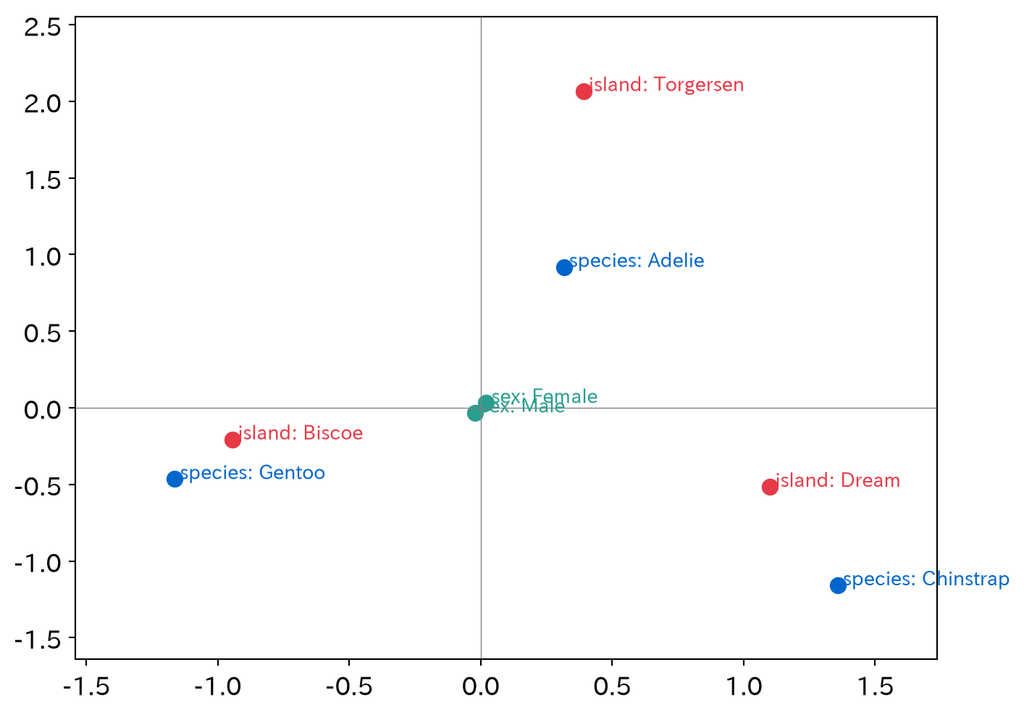

```python
cc = mca.column_coordinates(X_cat)
colors = {'species': '#0066cc', 'island': '#e63946', 'sex': '#2a9d8f'}
fig, ax = plt.subplots(figsize=(8, 6))
for name, (x, y) in cc.iterrows():
    var, cat = name.split('__')              # 例: 'species__Adelie'
    ax.scatter(x, y, color=colors[var], s=60)
    ax.text(x, y, f' {var}: {cat}', color=colors[var], fontsize=10)
ax.axhline(0, color='gray', lw=0.5)
ax.axvline(0, color='gray', lw=0.5)
ax.margins(0.15); plt.show()
```

GentooとBiscoe島が左に、ChinstrapとDream島が右下に、AdelieとTorgersen島が上に並びます。原点から同じ向きに離れているので、この3組が強く結びついています。第8回のクロス集計（ChinstrapはDream島だけ、GentooはBiscoe島だけ）と合っています。

性別（Female・Male）は、原点のすぐ近くです。どの種・どの島にも、雄と雌が同じくらいいるからです。

試すなら、`penguins['size'] = pd.cut(penguins['body_mass_g'], 3, labels=['軽', '中', '重'])`のように体重を3つの区分にして4つ目の区分に加え、地図がどう変わるか見てみましょう。